# The Evolving Cyber Threat Landscape

A Decade in Review: Global Cybersecurity Threats 2015-2024

Author

Patrick Lefler

Published

November 19, 2025

**NoteExecutive Summary**

**Strategic Recommendation:** Organizations must prioritize proactive threat intelligence, accelerate patch management cycles, and invest in AI-driven security operations to counter the evolving threat landscape.

## 1 The Financial Impact of Cyber Threats

### 1.1 Aggregate Losses by Year

[interactive chart not shown]

### 1.2 The Changing Face of Cyber Threats

[interactive chart not shown]

### 1.3 Financial Impact by Attack Type

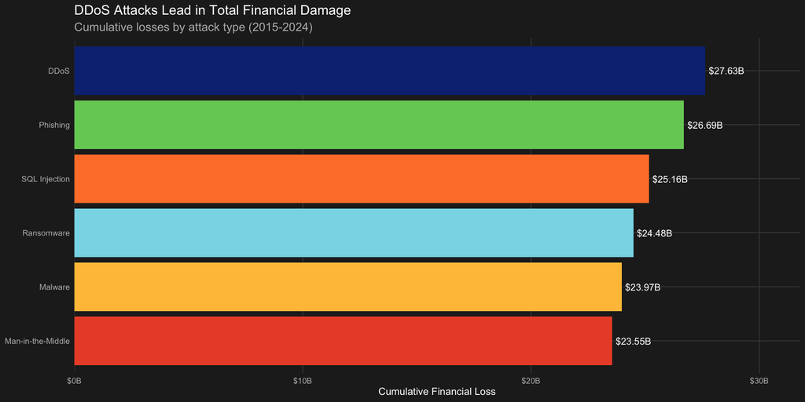

## 2 Industry Sector Analysis

### 2.1 Financial Impact Heatmap

[figure not shown]

Financial Loss Heatmap: Industry × Year

### 2.2 Most Targeted Industries

Industry Risk Profile

Cumulative metrics by target industry (2015-2024)

| Industry | Incidents | Cumulative Loss | Avg Loss/Incident | Avg Resolution | Users Affected |
| --- | --- | --- | --- | --- | --- |
| IT | 478 | $24.81B | $51.90M | 36.2 hrs | 250.09M |
| Banking | 445 | $22.77B | $51.17M | 35.7 hrs | 225.10M |
| Government | 403 | $21.21B | $52.62M | 37.6 hrs | 201.24M |
| Retail | 423 | $21.12B | $49.93M | 37.2 hrs | 206.78M |
| Healthcare | 429 | $21.04B | $49.05M | 35.8 hrs | 216.27M |
| Telecommunications | 403 | $20.46B | $50.77M | 37.1 hrs | 199.57M |
| Education | 419 | $20.07B | $47.90M | 35.9 hrs | 215.00M |

## 3 Geographic Threat Distribution

[interactive chart not shown]

## 4 Attack Sophistication Index

### 4.1 Vulnerability Type Analysis

[figure not shown]

[interactive chart not shown]

### 4.2 Attack Source Analysis

[interactive chart not shown]

## 5 Incident Response Effectiveness

### 5.1 Resolution Time Analysis

[interactive chart not shown]

### 5.2 Defense Mechanism Effectiveness

[interactive chart not shown]

## 6 2024 Emerging Trends

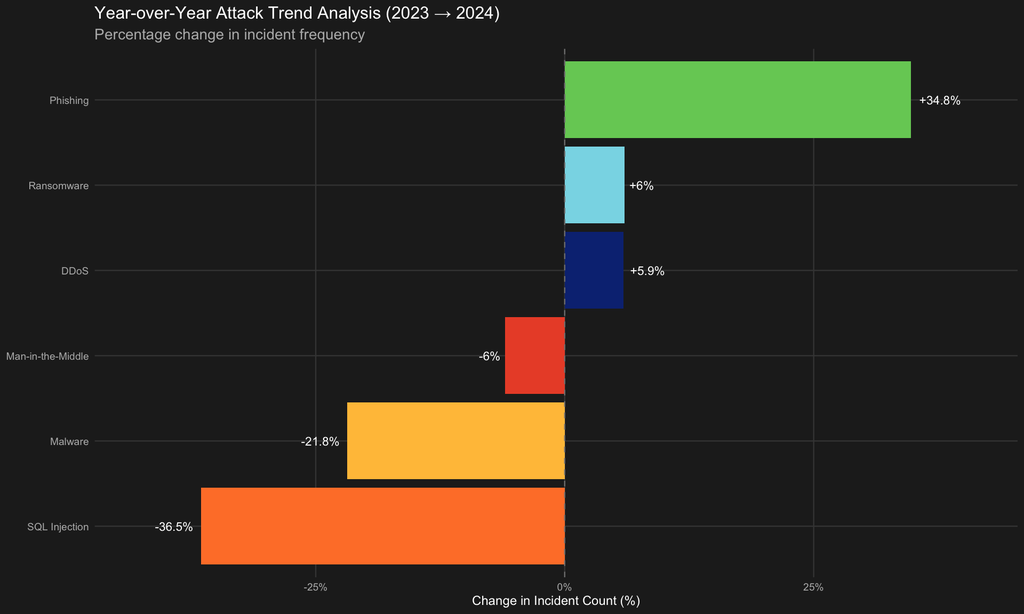

## 7 Methodology & Data Notes

**Coverage:** This analysis includes reported incidents from major economies (USA, China, India, UK, Germany, France, Russia, Japan, Brazil, Australia) across seven key industry sectors.

**Limitations:** This dataset represents documented and reported incidents. Actual incident volumes may be significantly higher due to underreporting, particularly in sectors with limited disclosure requirements.

**Analysis Approach:** Descriptive statistics, time series analysis, and comparative trend analysis using R statistical computing environment.

**TipAbout This Report**

This report utilizes the Global Cybersecurity Threats Dataset (2015-2024) that provides extensive data on cyberattacks, malware types, targeted industries, and affected countries. It is designed for threat intelligence analysis, cybersecurity trend forecasting, and machine learning model development to enhance global digital security.

This report was developed using R Quarto for reproducible analytics. All visualizations were created using the R ggplot2 and plotly packages.